# P3 - CommUTEC

July 10, 2020

## Parámetros del estudio

## Parámetros

**Tamaño de Muestra:** 180 encuestados

**Nivel de Confianza:** 95% Elegimos un nivel de confianza del 95% puesto que esto significancia que si hubiésemos hecho 20 muestreos y creado 20 intervalos de confianza; se esperaría que 19 de ellos contengan la media de la población. Lo cual representa un porcentaje bastante aceptable para una investigación. Además, 95% es el valor que usualmente se utiliza en este tipo de trabajos.

**Nivel de Significancia:** 0.05 El nivel de significancia para este caso estará dado por \(\alpha=0.05\), el cuál participa en el cálculo del nivel de confianza según la ecuación \(1-\alpha= \text{Nivel de confianza}\).

## Parámetros

**Tolerancia:** La tolerancia (epsilon) está dada en la fórmula: \[\mathbb{P}(\left\vert \overline{X}_n - \mu \right\vert \leq \varepsilon)\geq 1-\alpha\]

De la cual se llega a: \[\varepsilon=\frac{Z_a\sigma}{\sqrt{n}}\] \[a=\alpha/2\] Pero como Z es:

```
## [1] 1.96
```

## Parámetros

Finalmente la tolerancia quedaría como: \[\varepsilon=\frac{1.96 \sigma}{\sqrt{180}}\]

## Intervalos de confianza

## Intervalos de confianza

\[[\overline{X}-\varepsilon, \overline{X}+\varepsilon]\]

*EDAD:*

\[E_1 = 18.93599 \ \ \ \ \ \ \ E_2 = 19.41956\] \[\text{Intervalo de Confianza Edad} =[18.93599, 19.41956]\]

*TIEMPO DE TRANSPORTE*

\[T_1 = 93.50854 \ \ \ \ \ \ \ T_2 = 113.7248\] \[\text{Intervalo de Confianza Tiempo de Transporte}\] \[= [93.50854, 113.7248]\]

## Intervalos de confianza

*TIEMPO DE TRANSPORTE SEMANAL*

\[T_{S_1}=470.9605 \ \ \ \ \ \ \ T_{S_2}=576.8729\]

\[\text{Intervalo de Confianza del Tiempo de Transporte Semanal}\] \[= [470.9605, 576.8729]\]

*PROMEDIO PONDERADO:*

\[P_1=14.69495 \ \ \ \ \ \ \ P_2=15.2175\] \[\text{Intervalo de Confianza del Promedio Ponderado}\] \[= [14.69495, 15.2175]\]

## Intervalos de confianza

*HORAS DE SUEÑO:*

\[H_{S_1}=6.064808 \ \ \ \ \ \ \ H_{S_2}=6.401858\] \[\text{Intervalo de Confianza de Horas de Sueño}\] \[=[6.064808, 6.401858]\]

*NÚMERO DE REPROBADOS*

\[N_{R_1}=0.2222577 \ \ \ \ \ \ \ N_{R_2}=0.3888535\] \[\text{Intervalo de Confianza de Número de Reprobados}\] \[= [0.2222577, 0.3888535]\]

## Pruebas de hipótesis

## ¿Existe una relación entre la edad y el tiempo de transporte diario?

**H0:** A mayor la edad de los estudiantes, el tiempo de transporte diario es mayor.

**H1:** A mayor la edad de los estudiantes, el tiempo de transporte diario es menor.

**Como p-value es mayor que nuestro alpha, (0.2469>0.05)** no se puede descartar satisfactoriamente la hipótesis nula declarándola estadísticamente insignificante.

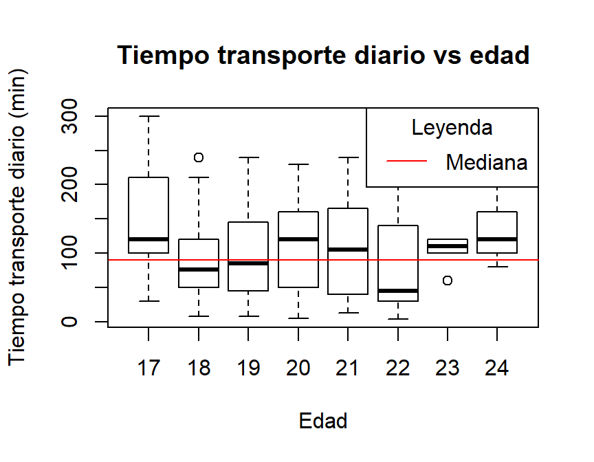

## ¿Existe alguna relación entre el tiempo que pasan en el transporte y la cantidad de cursos desaprobados del estudiante?

**H0:** Los alumnos que pasan un mayor tiempo al transportarse hacia la universidad tendrán un mayor número de cursos desaprobados.

**H1:** Los alumnos que pasan un mayor tiempo al transportarse hacia la universidad tendrán un menor número de cursos desaprobados.

**Como el p-value es mayor a nuestro alpha,(0.56>0.05)**, no es posible descartar satisfactoriamente la hipótesis nula declarándola estadísticamente insignificante.

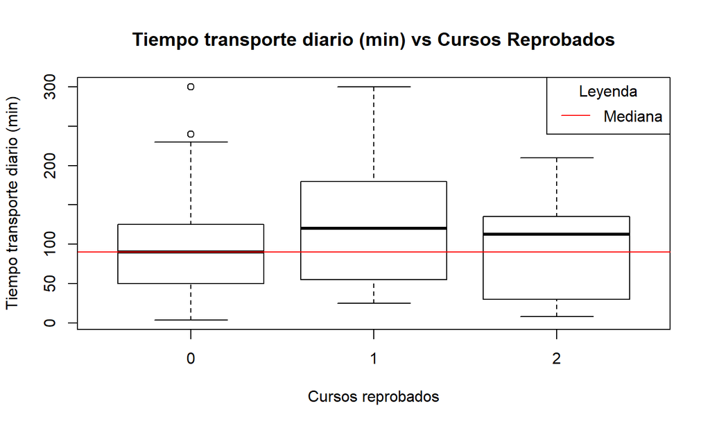

## ¿Existe alguna relación entre el tiempo que pasan en el transporte y el promedio del estudiante en el ciclo 2019-2?

**H0:** Los alumnos que pasan más tiempo transportándose tendrán un menor promedio ponderado.

**H1:**El tiempo ponderado sí influye en el promedio ponderado del alumno.

**Como el p-value es mayor a nuestro alpha,(0.9859>0.05)**, no es posible descartar satisfactoriamente la hipótesis nula declarándola estadísticamente insignificante.

```
## [1] "Mediana y media del promedio para un tiempo de transporte entre 0 y 100 minutos"
```

```
##    Min. 1st Qu.  Median    Mean 3rd Qu.    Max.
##   11.25   14.00   15.38   15.35   16.51   19.38
```

```
## [1] "Mediana y media del promedio para un tiempo de transporte entre 100 y 200 minutos"
```

```
##    Min. 1st Qu.  Median    Mean 3rd Qu.    Max.
##   10.65   13.04   14.15   14.24   15.60   17.25
```

```
## [1] "Mediana y media del promedio para un tiempo de transporte entre 200 y 300 minutos"
```

```
##    Min. 1st Qu.  Median    Mean 3rd Qu.    Max.
##   12.00   13.00   15.90   15.11   16.55   19.00
```

## ¿Existe alguna relación entre el grado de mérito del estudiante y las horas que se transporta semanalmente?

**H0:** Los alumnos que se transportan por poco tiempo tendrán un grado de mérito alto.

**H1:** Los alumnos que se transportan por poco tiempo no tendrán un grado de mérito más bajo.

**Como el p-value es mayor a alpha 0.7848>0.05**, no se puede rechazar la hipótesis H0.

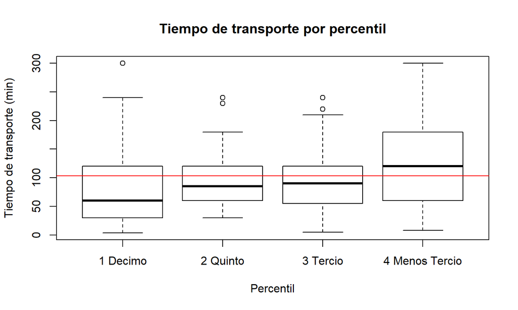

## ¿Existe alguna relación entre las horas que se transportan semanalmente y las horas que duermen diariamente los estudiantes?

**H0:** A menor tiempo de sueño del estudiante, mayor será el tiempo de transporte hacia la universidad.

**H1:** A menor tiempo de sueño del estudiante, menor será el tiempo de transporte hacia la universidad.

**Como el p-value es mayor a nuestro alpha,(0.1904>0.05)**, no es posible descartar satisfactoriamente la hipótesis nula declarándola estadísticamente insignificante.

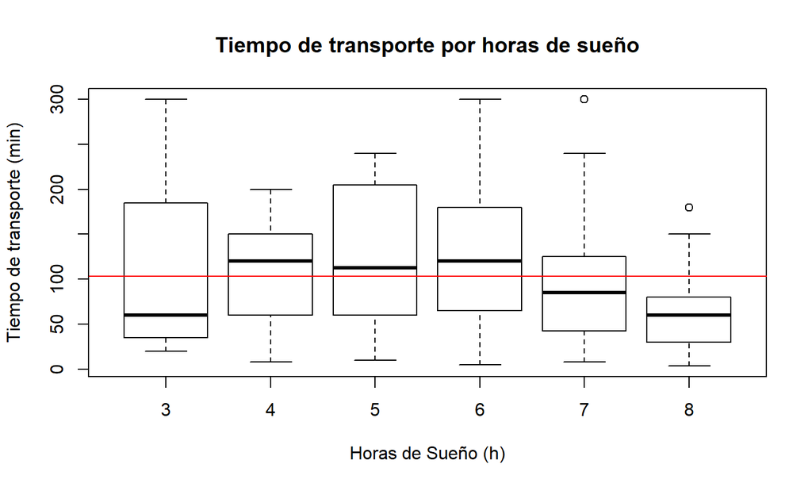

```
## [1] "Mediana y media del tiempo de transporte para 5 horas o menos de sueño"
```

```
##    Min. 1st Qu.  Median    Mean 3rd Qu.    Max.
##     8.0    60.0   105.0   115.8   190.0   300.0
```

```
## [1] "Mediana y media del tiempo de transporte para 6 horas o más de sueño"
```

```
##    Min. 1st Qu.  Median    Mean 3rd Qu.    Max.
##     4.0    50.0    90.0    99.8   135.0   300.0
```

## Conclusiones

## Conclusiones

**1.** No se halló una relación clara entre las variables de edad de los encuestados y tiempo de viaje, debido a que no se puede descartar satisfactoriamente la hipótesis 0 y no hay suficiente información que demuestre que la hipótesis 1 no se deba rechazar.

**2.**Al analizar el efecto del tiempo de transporte en la cantidad de cursos desaprobados y en el promedio ponderado, no se puede descartar satisfactoriamente la hipótesis nula, y al graficar los datos se hallaron ligeras tendencias. Sin embargo, aún es necesario analizar a más profundidad las relaciones entre estas variables, lo cual se podría lograr usando otros métodos, como la regresión.

## Bibliografía

- https://gestion.pe/tendencias/lima-ciudades-peor-trafico-269483-noticia/
- https://amp.milenio.com/especiales/estres-cronico-como-identificarlo